# R Notebook

```r
library(tidyverse)
library(janitor)
library(infer)
```

# MVP

## Task 1

Load the data again, clean_names(), and re-familiarise yourself with it

```r
ames <- read_csv("data/ames.csv") %>%
  clean_names()
```

## Task 2

Investigate the distribution of lot_area. Is the distribution roughly normal? If not, what problems do you find?

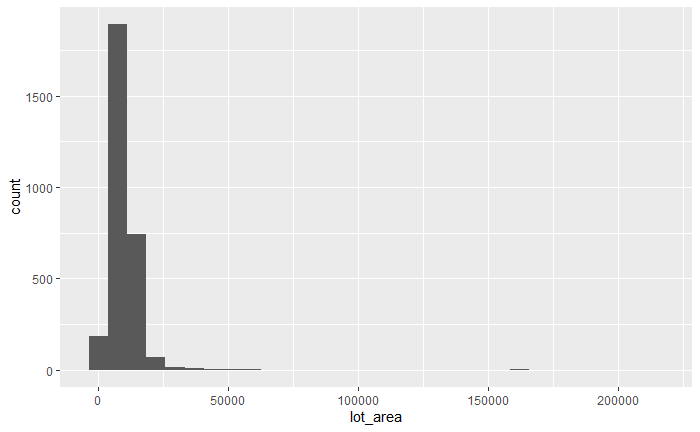

```r
ames %>%
  ggplot(aes(lot_area)) +
  geom_histogram(bins = 30)
```

Data doesn’t follow a normal distribution as it is has a long tail to the right, i.e. is skewed to the right.

## Task 3

Compute and visualise a bootstrap sampling distribution for the mean(lot_area) of the sold houses.

```r
resampled_ames <- ames %>%
  rep_sample_n(nrow(ames), reps = 10000, replace = TRUE)
```

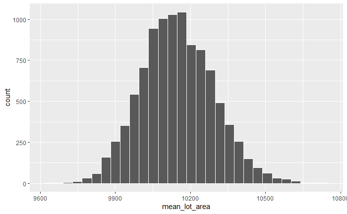

```r
summary_resampled_ames <- resampled_ames %>%
  summarise(mean_lot_area = mean(lot_area))

summary_resampled_ames %>%
  ggplot(aes(mean_lot_area)) +
  geom_histogram(col = "white")
```

## Task 4.

Use your bootstrap distribution to calculate a 95% CI for mean(lot_area), and visualise it on the distribution

```r
ci_95_resampled_ames <- summary_resampled_ames %>%
  summarise(lower_bound = quantile(mean_lot_area, 0.025),
            upper_bound = quantile(mean_lot_area, 0.975))

ci_95_resampled_ames
```

| lower_bound | upper_bound |
| --- | --- |
| 9877.5 | 10446.1 |

```r
NA
```

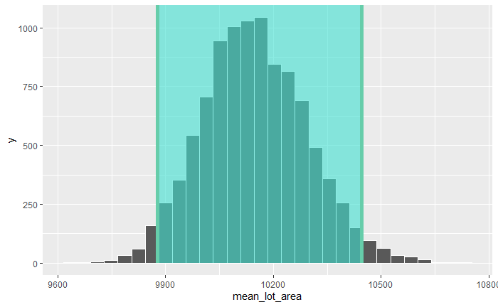

```r
summary_resampled_ames %>%
  ggplot(aes(mean_lot_area)) +
  geom_histogram(col = "white") +
  shade_ci(endpoints = ci_95_resampled_ames)
```

## Task 5.

You would like to know the mean(lot_area) of the sold houses with higher confidence. Calculate the 99% CI for this variable (you can re-use your bootstrap distribution from above). Is it narrower or broader than the 95% CI? Does that make sense?

```r
ci_99_resampled_ames <- summary_resampled_ames %>%
  summarise(lower_bound = quantile(mean_lot_area, 0.005),
            upper_bound = quantile(mean_lot_area, 0.995))

ci_99_resampled_ames
```

| lower_bound | upper_bound |
| --- | --- |
| 9804.981 | 10561.01 |

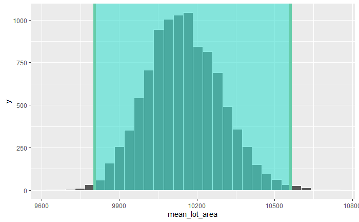

```r
summary_resampled_ames %>%
  ggplot(aes(mean_lot_area)) +
  geom_histogram(col = "white") +
  shade_ci(endpoints = ci_99_resampled_ames)
```

```r
NA
NA
```

The confidence interval is wider for the 99% CI vs the 95% CI. This makes sense as the 99% confidence interval ensures that 99% of the estimates of the mean lot area fall in its range, therefore the range needs to be alrger than that of the 95% CI value.

## Task 6.

Calculate the point estimate of the mean(lot_area)

```r
#point estimate of mean(lot_area) is the mean of the original sample data
ames %>%
  summarise(mean_lot_area = mean(lot_area))
```

| mean_lot_area |
| --- |
| 10147.92 |

```r
NA
```

# EXTENSION

## Task 1

Calculate a point estimate and 95% CI for the proportion of houses in the data built before 1920. Does the number of reps you use matter? [Investigate reps from 200 up to 50000, memory of your laptop permitting].

```r
# add column to indicate if the house was built pre-1920 or not.
ames_pre_1920 <- ames %>%
   mutate(built_pre_1920 = if_else(year_built < 1920, TRUE, FALSE),
          .after = year_built) %>%
  select(order, year_built, built_pre_1920)

# point estimate of original sample
pe_built_pre_1920 <- ames_pre_1920 %>%
  summarise(prop_built_pre_1920 = mean(built_pre_1920))

pe_built_pre_1920
```

| prop_built_pre_1920 |
| --- |
| 0.06006826 |

```r
NA
```

### 200 reps

```r
# bootstrapping based on 200 reps and full dataset (2,930 values) with replacement
ames_resampled_200 <- ames_pre_1920 %>%
  rep_sample_n(nrow(ames), reps = 200, replace = TRUE) %>%
  summarise(prop_built_pre_1920 = mean(built_pre_1920))

ames_resampled_200
```

| replicate | prop_built_pre_1920 |
| --- | --- |
| 1 | 0.06313993 |
| 2 | 0.07133106 |
| 3 | 0.06313993 |
| 4 | 0.05392491 |
| 5 | 0.05631399 |
| 6 | 0.06075085 |
| 7 | 0.05529010 |
| 8 | 0.05733788 |
| 9 | 0.06279863 |
| 10 | 0.05324232 |

[output cut: 190 more lines]

```r
NA
```

```r
# calculate 95% confidence interval
ci_ames_resampled_200 <- ames_resampled_200 %>%
  summarise(lower_bound = quantile(prop_built_pre_1920, 0.025),
            upper_bound = quantile(prop_built_pre_1920, 0.975))

ci_ames_resampled_200
```

| lower_bound | upper_bound |
| --- | --- |
| 0.0518686 | 0.06965017 |

```r
NA
```

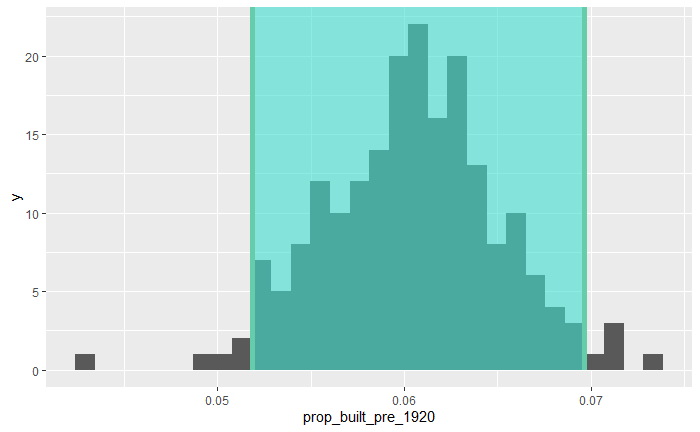

```r
# plot histogram of resampled data
ames_resampled_200 %>%
  ggplot(aes(prop_built_pre_1920)) +
  geom_histogram() +
  shade_ci(endpoints = ci_ames_resampled_200)
```

### 50,000 reps

```r
# bootstrapping based on 200 reps and full dataset (2,930 values) with replacement
ames_resampled_50000 <- ames_pre_1920 %>%
  rep_sample_n(nrow(ames), reps = 50000, replace = TRUE) %>%
  summarise(prop_built_pre_1920 = mean(built_pre_1920))

ames_resampled_50000
```

| replicate | prop_built_pre_1920 |
| --- | --- |
| 1 | 0.06484642 |
| 2 | 0.06211604 |
| 3 | 0.05460751 |
| 4 | 0.06075085 |
| 5 | 0.05051195 |
| 6 | 0.05597270 |
| 7 | 0.06211604 |
| 8 | 0.05460751 |
| 9 | 0.06484642 |
| 10 | 0.06416382 |

[output cut: 990 more lines]

```r
NA
```

```r
# calculate 95% confidence interval
ci_ames_resampled_50000 <- ames_resampled_50000 %>%
  summarise(lower_bound = quantile(prop_built_pre_1920, 0.025),
            upper_bound = quantile(prop_built_pre_1920, 0.975))

ci_ames_resampled_50000
```

| lower_bound | upper_bound |
| --- | --- |
| 0.05153584 | 0.06860068 |

```r
NA
```

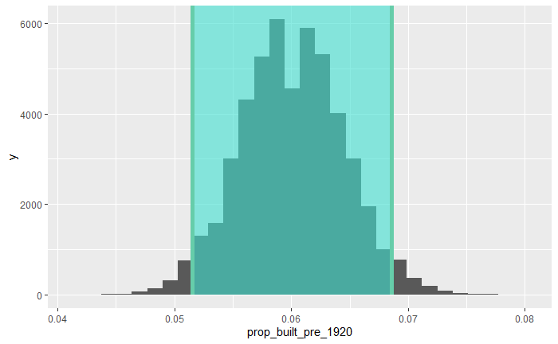

```r
# plot histogram of resampled data
ames_resampled_50000 %>%
  ggplot(aes(prop_built_pre_1920)) +
  geom_histogram() +
  shade_ci(endpoints = ci_ames_resampled_50000)
```

```r
# combine outputs of both tests
ci_ames_resampled_200 %>%
  union(ci_ames_resampled_50000) %>%
  mutate(reps = c(200, 50000), .before = lower_bound) %>%
  mutate(ci_range = upper_bound - lower_bound)
```

| reps | lower_bound | upper_bound | ci_range |
| --- | --- | --- | --- |
| 200 | 0.05186860 | 0.06965017 | 0.01778157 |
| 50000 | 0.05153584 | 0.06860068 | 0.01706485 |

```r
NA
NA
```

Between 200 and 50,000 reps there is negligible difference between the confidence intervals. The range is slightly tighter with the 50,000 reps however the two methods appear to be very similar despite the significant increase in the computational power to process the 50,000 reps method. This has demonstrated that the number of reps is beneficial up to a point, after which the difference in accuracy is negligible.